# OPMT 2206

Chris Butterworth

# Introduction to OPMT 2206

OPMT 2206 : Quality Assurance 2 (Manufacturing)

This is the second course in Quality Assurance in this stream and students will learn several new tools to further develop their understanding of Quality Assurance with an emphasis on manufacturing applications.

## Careers in Quality

A career in Quality means continually improving products and processes and solving problems. Quality practitioners serve their organizations by making them better, more competitive. Employees in this field make sure that the customer’s interests are being looked after. The Quality department is really the customer’s representative inside the organization.

There are many different types of carreers in Quality ranging from the generalist to the technically-skilled specialist. A quick look through indeed.ca with the search term “Quality Asssurance” in Vancouver shows several openings including;

- Quality Assurance Tester
- Quality Assurance Assistant
- Quality Assurance Engineer
- Quality Assurance Coordinator
- Quality Manager

and many more, recently posted job ads.

In manufacturing, many (most?) companies will have some form of a Quality Management System in place and so will have a Quality Manager to lead that role. As these companies grow, and see the need for and benefits of Quality management, positions in Quality also expand and can include;

- Quality Manager
- Quality Auditor
- Quality Inspector
- Quality Technician
- Document Control Coordinator
- Calibration Technician

If you are considering a career in Quality, it would be useful to look into salary ranges as well as required skills. If you’re comfortable with data and statistics, there are many, well-paying careers in Quality control that require these numerical skills.

If you prefer order,standard work and Good Manufacturing Practices then Quality Assurance is more suited to you and employment in management, auditing, document control and similar positions would be good career choices.

## The American Society for Quality

The American Society for Quality (ASQ), formerly the American Society for Quality Control (ASQC), is a knowledge-based global community of quality professionals, with nearly 80,000 members dedicated to promoting and advancing quality tools, principles, and practices in their workplaces and communities. (Wikipedia)

Why ASQ?

ASQ offers you access to the tools, techniques and insights that can help distinguish an ordinary career from an extraordinary one.

- Unparalleled knowledge resources in the ASQ Quality Resources and in the Books & Standards store
- Advanced education, training and certification
- A wide range of topical solutions from webinars and articles to case studies and quality tools
- Access to industry events and conferences, including the annual World Conference on Quality and Improvement
- Career-boosting support in ASQ’s Career Center

ASQ offers 18 professional certifications relating to various aspects of the quality profession.

CQIA - Certified Quality Improvement Associate  
CQPA - Certified Quality Process Analyst  
CQI - Certified Quality Inspector  
CQT - Certified Quality Technician  
CCT - Certified Calibration Technician  
CQA - Certified Quality Auditor  
CBA - Certified Biomedical Auditor  
CHA - Certified HACCP (Food Safety) Auditor  
CPGP - Certified Pharmaceutical GMP Professional  
CSQP - Certified Supplier Quality Professional  
CRE - Certified Reliability Engineer  
CQE - Certified Quality Engineer  
CSQE - Certified Software Quality Engineer  
CSSYB - Certified Six Sigma Yellow Belt  
CSSGB - Certified Six Sigma Green Belt  
CSSBB - Certified Six Sigma Black Belt  
CMBB - Certified Master Black Belt  
CMQ/OE - Certified Manager of Quality and Organizational Excellence

Joining the ASQ Global quality community gives you a strong competitive advantage. For people passionate about improvement, ASQ is the global knowledge network that links the best ideas, tools, and experts - because ASQ has the reputation and reach to bring together the diverse quality and continuous improvement champions who are transforming our world.

- 75,000 individual and organizational members in 130 countries
- 250 sections and local member communities
- 25 forums and divisions covering industries and topics
- 200+ training courses (source: ASQ.org).

# Quality Management

Linked here is a brief article on the History of Quality in Industry

https://prod-ng.sandia.gov/techlib-noauth/access-control.cgi/2012/127060.pdf

## ISO 9001

There have been many Quality Management publications around the world created to improve competitiveness in industry.

Britain - BS 5750  
Canada - Z299 Series  
USA - MIL-Q-9858A  
NATO - AQAP Standards

Here’s a link to the ISO story

https://www.iso.org/the-iso-story.html#0

The ISO 9000 series of Quality Maagement standards were published in 1987 and are the best known standards for Quality in the world.

These standards are revised every seven or eight years. The current version is ISO 9000:2015.

The standard covers many aspects of a business. I will discuss some (not all) of the requirements so you can get a feel for what such a system entails and also what it can do for a company.

### Seven Quality Management Principles

ISO 9001, as well as many other Quality management standards, is based on seven Quality Management Principles to promote organizational improvement. These principles are described here;

#### Customer Focus

Understand the needs of existing and future customers  
Meet customer requirements  
Measure customer satisfaction  
Learn more about the customer experience and customer satisfaction.

When you satisfy your customer, they are likely to return with more business.

#### Leadership

Establish a vision and direction for the organization  
Set challenging goals  
Equip and empower employees  
Recognize employee contributions  
Learn more about leadership.

Leaders should encourage a commitment to Quality throughout the company.

#### Engagement of people

Ensure that people’s abilities are used and valued  
Make people accountable  
Enable participation in continual improvement  
Enable open discussion of problems and constraints  
Learn more about employee involvement.

Leaders at all levels should encourage participation and acknowledge contributions of all employees.

#### Process approach

Manage activities as processes  
Measure the capability of activities  
Identify linkages between activities  
Prioritize improvement opportunities  
Learn more about a process view of work and see process analysis tools.

Understand the risks that can affect the output of business and industrial processes.

#### Improvement

Improve organizational performance and capabilities  
Empower people to make improvements  
Measure improvement consistently  
Celebrate improvements  
Learn more about approaches to continual improvement.

Successful companies keep an eye on improvement activity.

#### Evidence-based decision making

Ensure the accessibility of accurate and reliable data  
Use appropriate methods to analyze data  
Make decisions based on analysis  
Balance data analysis with practical experience  
See tools for decision making.

Decisions based on the analysis of data are more likley to be correct and more likely to produce the right results.

#### Relationship management

Identify and select suppliers to manage costs, optimize resources, and create value  
Establish relationships considering both the short and long term  
Share expertise, resources, information, and plans with partners  
Collaborate on improvement and development activities

A good read on these principles can be found at this link;

https://www.iso.org/files/live/sites/isoorg/files/archive/pdf/en/pub100080.pdf

### Documentation in a ISO 9001:2015

The pyramid below depicts the structure of the documentation in a QMS such as ISO 9001.

At the top level is the Quality Manual. This document, just a few pages, contains;  
a description of the QMS  
identifies the person(s) appointed as Quality Representative  
identifies the Quality Objectives  
contains Quality policies  
and more

The next two levels are Procedures and Work Instructions. They usually differ in just a couple ways. Procedures tend to be related to management activities and can be a little less specific. Work instructions tend to be associated with product (service) activities and need to be specific to minimize risk.

The bottom layer of the pyramid identifies the Quality records. When an inspection form is filled out, it becomes a record. When an emplyee completes training, the training form is filled out ad it becomes a record. Records are the company’s objective evidence of compliance to its own QMS.

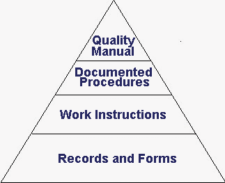

Quality Pyramid

Statements of policy are difficult for some companies. Boilerplate statements are common.  
“ABC Mfg strives to meet or exceed customer requirements”

“Only Qualified technicians can sign calibration certificates”  
“All customer complaints are managed by the Quality Committee”  
“Only Accepted (green label) products are issued to Production”

Quality Objectives can also be tricky. Consider the following;

“Will provide yellow belt training for all employees”  
“Gain ISO 9001 certification” “Develop, issue and analyse Customer Satisfaction survey”

Objectives should be SMART

Specific Measurable Attainable Relevant Time limited

Procedures (Standard Operating Procedures - SOPs), are very beneficial in defining how to accomplish certain activities. Some examples include;

**Document Control** - such a procedure would include revision control, master list, authorities (who can approve, amend).

**Control of Nonconforming Product** - when an item is found to be nonconforming (e.g. it failed an inspection point), you need to;

identify that item so it is clear that it is not to be used  
segregate that item  
investigate the scope of the nonconformity - perhaps there are others  
document this activity (e.g. NCR form)  
Depending on the nature of the problem, you may want to issue a Corrective Action Request. This will require somone to;

determine a root cause  
implement a solution  
validate the solution

**Customer Complaint Handling** - obviously a very important activity so it is well worth defining a few key steps to ensure that the customer is always in the loop regarding the complaint and is satisfied with the results.

**Calibration Procedure** - the SOP would be high level activity and include the scope of equipment as well as calibration intervals. Each individual calibration procedure (for calipers, weigh scales, thermometers etc) would include the specific details related to a particular piece of measuring equipment.

**Product Development** - this activity is where we can get many things wrong. So it is valuable to have a procedure, such as the APQP or Stage-Gate method for developing new products.

**Internal Audit Procedure** - your QMS will require frequent audits where auditors (your employees or outside experts) will assess work activity to ensure that practices are aligned with procedures and regulations.

Below the Procedures are the Work Instructions and this includes Inspection procedures. These are the task-specific instructions describing in detail, how the work should be carried out. Examples could include;

Packaging Instructions for Medical Products  
Calibration Procedure for Calipers  
Method for Performing Titration on Electrolyte

With many SOPs, Insructions etc, there will also be related forms that need to be filled out. Once filled, these forms become Quality Records - the base layer of the pyramid.

NCR form  
Calibration Certificate  
Test Record  
Training Record  
Audit Report  
Inspection Record

These are just a few of the documents you will use in your organization as part of the QMS.

# Lean Manufacturing

# Six Sigma

# Quality in Manufacturing

## Cost of Quality

The Cost of Quality in an organization is the amount of money we spend trying to make a quality product **plus** the amount we spend when we fail to do so.

Money spent trying to make a quality product falls into two cost categories: Prevention and Appraisal.

Prevention costs are incurred to prevent quality problems. These costs are associated with the implementation, and maintenance of the quality management system (e.g. ISO 9001).

Other prevention costs include;

statistical process control employee training Quality planning product development testing

Appraisal costs are, as the name suggests, those costs associated with measurement and evaluation. Elements in this category include;

incoming inspection final inspection measuring equipment calibration wages of inspectors supplier evaluation Quality audits

The money we spend when we have a quality problem falls into two cost categories: Internal Failure and External Failure

Internal failure costs are associated with the costs to deal with defects that have been detected while the product(s) are still within the factory. These costs include;

scrap - product that is defective and cannot be repaired  
rework  
Nonconformance reporting and corrective action request costs

External failure costs are a different category and the numbers are typically much higher. When a product fails in your customers’ hands, you have additional costs such as;

field replacement costs - often FedEx Overnight  
lot rejection - customer may retun the entire shipment  
field service - may need to send someone out to the customer site  
legal costs

When your customer starts looking at your competitors, you may start to lose business. External failure costs are the highest.

The distribution of these costs can be described with the following chart.

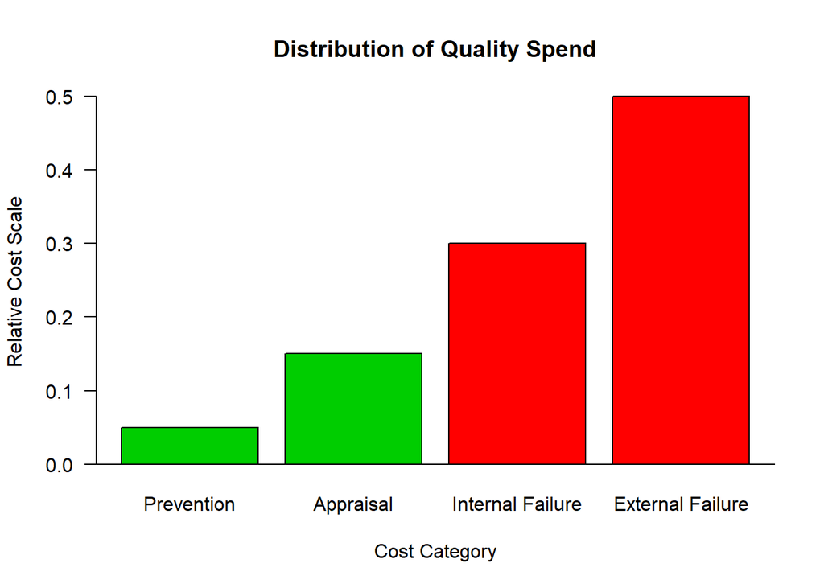

```r
barplot(c(0.05, 0.15, 0.30, 0.50), names.arg= c("Prevention", "Appraisal", "Internal Failure", "External Failure"), col = c(3,3,2,2), xlab = "Cost Category", ylab = "Relative Cost Scale", main = "Distribution of Quality Spend", las = 1)
abline(h=0)
```

As we see, the majority of our quality costs are dealing with failures. Solving costly quality problems puts money back to the bottom line where it belongs.

## Process Mapping

## Industrial Problem Solving

Problem solving is a highly valuable skill. Companies lose a lot of money due to quality problems. Simple problems tend to get corrected but complex problems aren’t easily fixed. They are elusive and their costs continue on. Often, these are chronic problems that companies have come to accept as part of the process.

One of the issues that affects our ability to solve complex problems is our comfort level with numbers. We overlook things like minimum required sample sizes and confidence levels. Additionally, we do not use tools like regression analysis and design of experiments. Instead, we often look for a smoking gun to show up in a meeting.

### The Need for Problem Solving Talent

Companies start out with great ideas, lots of talent and other resources. But when production starts, new issues emerge. There are defects at various stages of manufacture as well as field failures. These unexpecetd problems eat up too much of a company’s profits.

Consider a defect in a manufacturing company. The cost for that part will be known (should be) but that isn’t the whole cost of the defect. Often times, the defect will require a nonconformance report (NCR) or similar document that consumes management time and attention. In a quality organization, there may also be a corrective action request (CAR) document that consumes additional resources. And unfortunately, in many cases, the corrective action proves ineffective when the defect re-appears.

There have been many surveys of employers regarding the skills needed for the worksplace and Problem Solving often ranks at or near the top. Below is a chart of survey results from Canadian Manufacturers and Exporters as reported in the magazine 20/20.

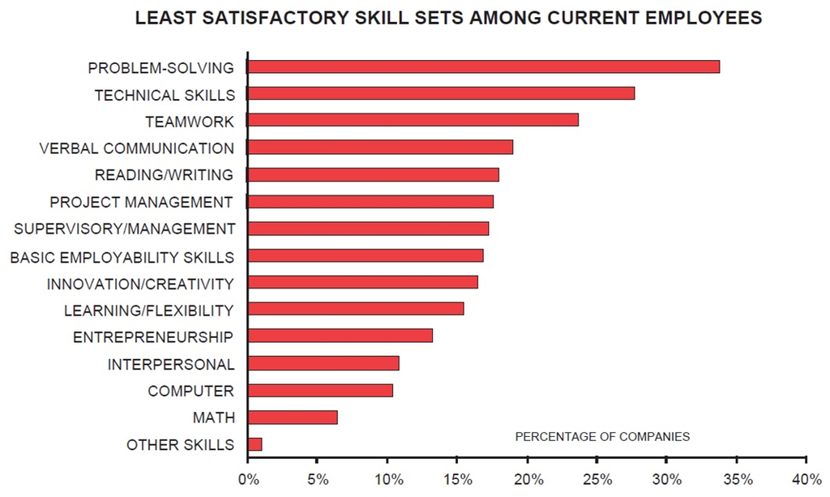

from 20 / 20 magazine

### Factory Complexity

Manufacturing is a complex system of many processes. Each process either adds, removes or deforms material.

**Adding**

- assembly
- welding
- mixing
- coating

**Removing**

- cutting
- machining
- etching
- punching

**Deforming**

- extruding
- molding
- heat treating
- stamping

And the list goes on. The main idea here is that at each process, there are many variables at play and each variable is a potential driver of product quality. That is to say that each varaiable could be a root cause of a quality problem.

Consider the factory floor from a high level. There are many processes and each typically is performed at one workstation.

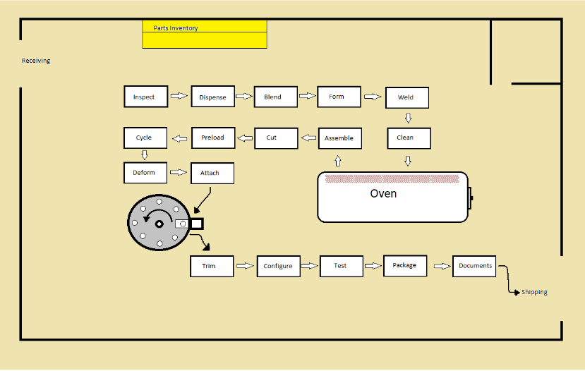

Factory Floor

Zoom in on one workstation - mixing. Here we have three materials - two liquid and one powder - being mixed together in a large mixing bowl.  
The raw materials all came from an upstream process and each of the three are the result of an upstream process.They have their own features and quality characteristics that vary. The density in one batch will be different than another batch, and so on.  
The mixing process also has variability. Cycle time, mix speed, blade geometry, bowl temperature and more. So it isn’t surprising that quality problems are elusive when the process that generated the problems is a complex multivariable process.

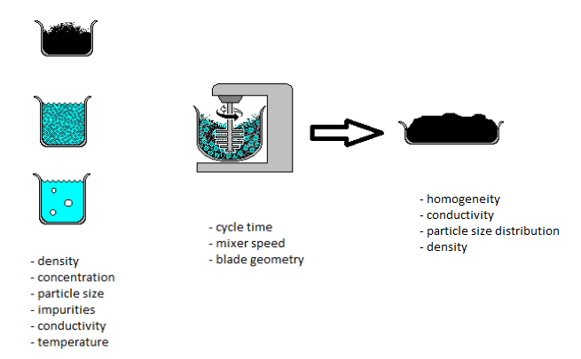

Mixing Process

Problem solving in a manufacturing environment boils down to an **ability to connect the dots.** Something is causing the defect and it is likely detectable within our factory. We need to develop the analytical skills necessary to understand and dig into such complexity.

Before discussing some of the different tools avainlable for the problem solver, it is useful to consider the different types of data that we will encounter in a manufacturing setting.

### Data Types

at the highest level we have two kinds of data: Quantitative and Qualitative

Quantitative: a number - a measurement - a count - dimensions height, weight, temperature, diameter, tensile strength, torque, number of defective items in a batch, etc

Qualitative: a classification or a judgement, not a measurement but a subjective evaluation - for example, we often classify items according to visual acceptance criteria e.g. colour, greyness, glossiness, clarity. When we make a judgement, it’s qualitative

Quantitative breaks down into two types: Continuous and Discrete.

Discrete is usually integers - the number of defects in a lot, number of potholes in a mile of road, etc

Continuous is usually the result of a measurement. If you weigh an item you can get two, three or more decimal places if you get better and better scales. Therefore, Continuous has an’infinite’ number of possibilities, dependent on the resolution of your measurement device.

Qualitative data breaks down into three main types: Binary, Nominal and Ordinal

Binary data categorizes things into one of two mutually exclusive bins: Good/Bad, Pass/Fail, Accept/Reject. The item is either broken or not. There is no third category. This data type is very often used in Quality Inspection in Manufacturing companies

Nominal is a category where there is no order. None could be said to be higher or lower than another. For example: the colour of supplied resins could be red, green, white, orange, brown.

Ordinal is a category where order does matter. For example, low, medium and high.

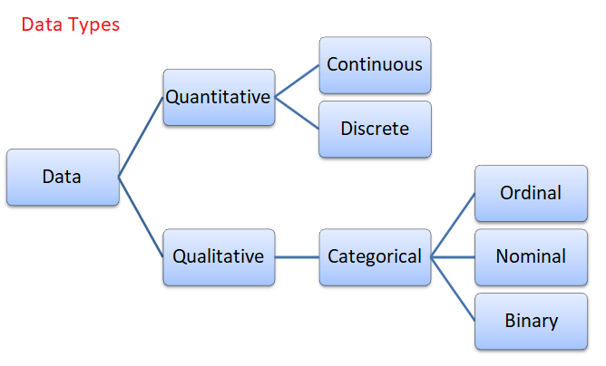

The statistical tools available depend on the type of data that you have to analyse.

Take, for example, a data set on weights from components used in an assembly. All you have is a number (weight) and a category (item). A boxplot (or dotplot) is useful for viewing this type of data.

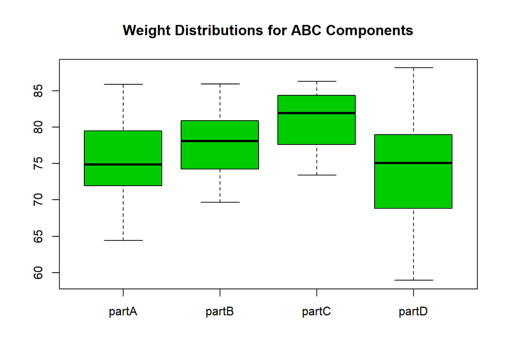

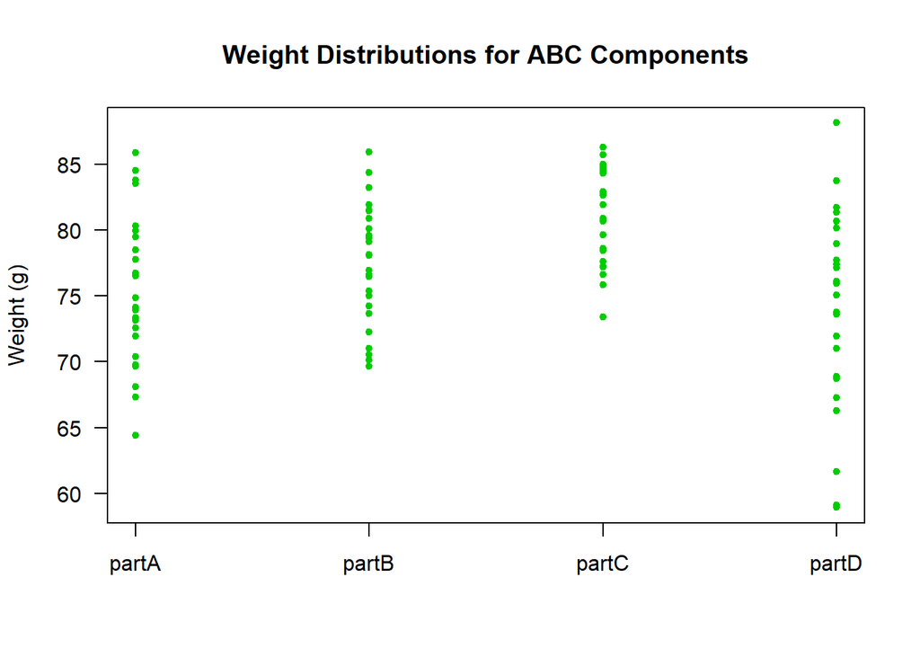

Now consider that you have data on the hardness of some steel bars as well as the percentage of Carbon in the steel. Both of these variables are continuous. Such data lends itself to a scatterplot (pairs plot).

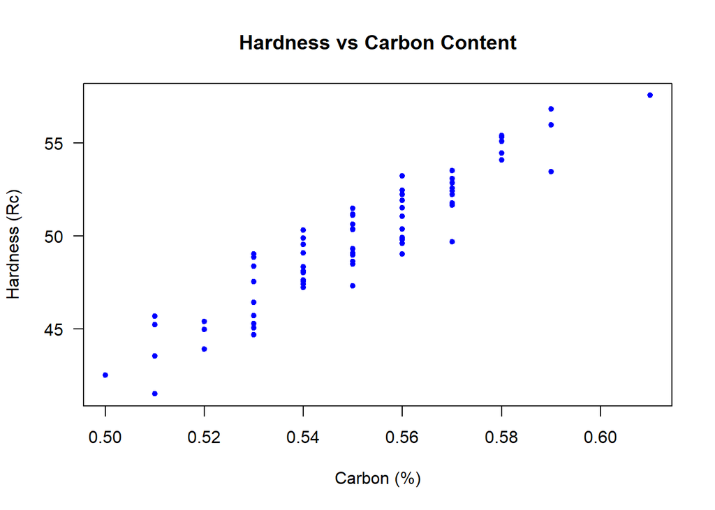

# Product Development Tools

## Quality Function Deployment

## Failure Mode and Effects Analysis

## Stage-Gate Process

## Advanced Product Quality Planning

APQP is a structured approach to product and process design. It is a set of quality requirements that helps suppliers to design a product (and process) that satisfies the customer.

Quality Planning can be complex. There are many tools, methods, documentation requirements, product and process requirements and more. The APQP manual helps companies by defining the required inputs and outputs at each stage of product development.

APQP was created in the late 1980s for automotive parts suppliers to the big three - Ford, Chrysler and General Motors. This is now standard practice in many manufacturing industries.

APQP breaks the product development process into four phases. There is a list of required inputs and outputs for each phase. The diagram below depicts this process.

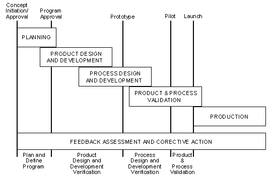

APQP Four Phases

Phase 1 - Planning

This initial phase is about understanding the customer requirements and determining what product characteristics will meet these requirements.

Phase 2 - Product Design and Development

The focus in this phase is to end up with a complete set of product design documents.

Phase 3 - Process Design and Development

This phase looks at the manufacturing processes that will produce the end product. The deliverables in this phase include a process flowchart, measurement system studies, floor plan payout, packaging requirements, inspection points and more.

Phase 4 - Product and Process Validation

This is the test phase and will include a production trial run. At the endo of this phase you should have a Quality planning sign-off.

The image below shows the varfious output requirements at each phase.

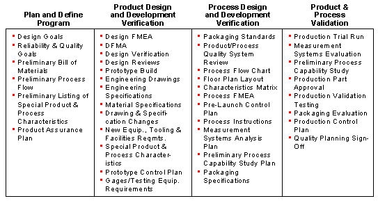

APQP Outputs

## Design of Experiments

# Supplier Quality Management

## Supplier Quality Records

## Incoming Quality Control

# Reliability

# Quality Audits